# **Instituto Tecnológico y de Estudios Superiores de Monterrey**

# Fase 3: Preparación de los datos

### 1. Describe con tus palabras en qué consiste la Fase 3: Preparación de los datos

Esta etapa consiste en realizar las actividades necesarias para tener los datos listos y sin errores que se ocuparan para el análisis el cual dará solución a la problemática previamente planteada. Dichas actividades consisten en:

- Seleccionar los datos: se deben seleccionar los registros y atributos que son necesarios, ya que, no es necesario tener muchos o todos los datos si solo se ocuparan cinco campos para llegar a la solución.
- Limpiar los datos: es necesario eliminar o reemplazar los valores nulos o faltantes, para que al momento de hacer los cálculos no nos arroje un error, o esos campos nulos nos alteren el resultado.
- Generar nuevos datos: se deberán analizar los datos para determinar si es necesario en este paso agregar registros o derivar atributos.
- Integrar los datos: aquí se determinará si se puede o si es necesario fusionar algunos datos e inclusive agregar algunos otros.
- Dar formato a los datos: es necesario que los datos estén estandarizados, para poder hacer las conexiones entre sí, además de que se deben ordenar para poder modelarlos.
- Dividir los datos en conjuntos: con el propósito de entrenamiento y prueba.

### 1. ¿Qué datos hay que seleccionar? Por qué.

Hay que seleccionar los datos del tipo de cambio fijo o variable, la inflación en México y en Estados Unidos como variables independientes, así como el valor final del tipo de cambio como variable dependiente, esto es porque estas variables sí son relevantes y podrían tener una correlación lo suficientemente significativa para hacer un modelo explicativo. Eso no se podría decir de las variables de los meses, debido a que esas variables únicamente representan el periodo en el tiempo en el que se registraron los demás datos. No representan una variable coyuntural que pueda ayudar a predecir el comportamiento del tipo de cambio.

### 2. ¿Hay que eliminar o reemplazar valores en blanco? Sí / No / Por qué

No hay que eliminar o reemplazar los valores en blanco debido a que no hay datos faltantes (nulos) que requieran ser llenados o reemplazados.

### 3. ¿Es posible agregar más datos? Sí / No / Por qué.

Analizando los registros, se concluye que no es necesario agregar más datos, ya que estos son mayores al mínimo de registros necesarios.

### 4. ¿Hay qué integrar o fusionar datos de varias fuentes? Sí / No / Por qué.

No, debido a que los datos de esa base son suficientes para hacer el análisis, por lo que no sería necesario utilizar otra fuente para adquirir datos adicionales.

### 5. ¿Es necesario ordenar los datos para el análisis? Sí / No / Por qué.

Los datos se encuentran ordenados por mes y año, es decir: son una serie de tiempo. Es común que en datos de series de tiempo hayan patrones en el error de modelo que hagan que este no sea bueno para predecir, por ende aleatorizamos los datos en nuestra muestra de testeo para eliminar ese sesgo.

### 6. ¿Tengo que hacer conjuntos de datos para entrenamiento y prueba? Sí / No / Por qué.

Sí, debido a que de esa manera se podría saber con anticipación si el modelo sirve o no para explicar la variable independiente.

Esto podría darnos un poco más de seguridad de que los datos del modelo son aptos para hacer predicciones respecto a la variable dependiente. Y si no lo son, habría que modificarlos hasta que la prueba salga bien. En nuestro caso hicimos un test size de 0.2 con un training size de 0.8.

### 7. ¿Qué ajustes se tuvieron que hacer a los datos (agregar, integrar, modificar registros (filas), cambiar atributos (columnas)?

Ningún ajuste fue necesario hacer a los datos, ya que, no hubo datos faltantes ni atributos que no fueran relevantes.

```python
df.isnull().any #Detectar valores nulos
```

```
<bound method DataFrame.any of        Mes  Mes.1    T.C  Inf.Mex  Inf.US  Fijo.Variable
0    False  False  False    False   False          False
1    False  False  False    False   False          False
2    False  False  False    False   False          False
3    False  False  False    False   False          False
4    False  False  False    False   False          False
..     ...    ...    ...      ...     ...            ...
187  False  False  False    False   False          False
188  False  False  False    False   False          False
189  False  False  False    False   False          False
190  False  False  False    False   False          False
191  False  False  False    False   False          False

[192 rows x 6 columns]>
```

```python
df.isnull().values.any()
```

```
False
```

```python
df.isnull().sum()
```

```
Mes              0
Mes.1            0
T.C              0
Inf.Mex          0
Inf.US           0
Fijo.Variable    0
dtype: int64
```

```python
df = df.drop_duplicates() #Eliminar los valores duplicados
```

```python
df.shape
```

```
(192, 6)
```

Variables independientes y dependientes

```python
df.columns
```

```
Index(['Mes', 'Mes.1', 'T.C', 'Inf.Mex', 'Inf.US', 'Fijo.Variable'], dtype='object')
```

```python
x = df[['Inf.Mex','Inf.US','Fijo.Variable']] #variable de entrada
y = df["T.C"] #Variable de salida
```

División de los datos en conjunto de entrenamiento y prueba

```python
from sklearn.model_selection import train_test_split
```

```python
x_train, x_test, y_train, y_test = train_test_split(x, y, test_size = 0.2, random_state = 0, shuffle = True ) #Librería para dividir los datos
```

```python
print(x_test)
```

```
     Inf.Mex  Inf.US  Fijo.Variable
110     18.3     1.8              2
74      43.8     2.8              2
163      4.0     2.2              2
97      15.4     1.4              2
126      9.1     3.7              2
71      52.0     2.5              2
18      22.0     4.4              1
157      5.5     3.0              2
145      4.8     1.1              2
7       28.1     5.6              1
5       26.1     4.7              1
139      5.9     2.7              2
158      5.6     3.1              2
170      4.2     1.8              2
```

[output cut: 25 more lines]

# Fase 4: Modelación de los datos

### 1. Describe con tus palabras en qué consiste la Fase 4: Modelación de los datos

Esta etapa ocupa herramientas como python, pandas, sklearn, etc. para resolver la problemática planteada en la hipótesis, basándose en un algoritmo de Machine Learning. Básicamente aquí tomaremos los resultados de la regresión lineal del modelo para determinar si finalmente fue bueno para predecir el comportamiento de la variable. Esto se haría observando los indicadores finales de la estadística descriptiva de los datos, los coeficientes de regresión, los valores actuales obtenidos para compararlos con los de la predicción del modelo, el coeficiente de determinación y la gráfica del modelo. Estos indicadores nos dan una buena imagen de qué tanto explica el modelo al comportamiento de los datos, los coeficientes lo hacen por medio de explicar el cambio promedio en Y ante un cambio en su respectiva X, las diferencias entre valores actuales y de predicción al mostrar qué tan grande es el error, la gráfica para notar diferencias entre el comportamiento actual y el predecido, etc.

Cabe mencionar que el elemento que hace la diferencia entre si el modelo es bueno para explicar el comportamiento del tipo de cambio o no, es el coeficiente de determinación. Necesita ser mayor a 0.7 para ser considerado bueno, y es ideal que se acerque a 1. Pues este coeficiente representa el porcentaje de los datos que son explicados por el modelo. Si este es menor a 0.7, se tendrá que correr el modelo las veces necesarias, haciendo modificaciones hasta que el coeficiente sea bueno.

### 1. ¿Cuántos intentos o corridas realizaste para obtener los resultados sin errores? Porqué

No tuvimos que hacer muchos intentos de corrida para obtener los resultados sin errores debido a que las fórmulas que utilizamos para los ejercicios en clase eran prácticamente las mismas que necesitábamos para validar nuestro modelo. Sin embargo, sí tuvimos que hacer un segundo intento para que corriera, pero eso se debió a que en un momento la base de datos se había borrado por el tiempo que había pasado desde la última vez que entramos al documento. Esto debido a que en la aplicación de collaboratory, se borra el documento subido cuando se rebasa un límite de tiempo que permite almacenarlo.

### 2. ¿Cómo resolviste los problemas que se presentaron?

Volviendo a subir el documento para que corrieran nuevamente los códigos que ya teníamos.

### 3. ¿Qué resultados arrojó el análisis? Incluye imagen de cada resultado y explica cada uno de los resultados:

#### 1. Estadística descriptiva

La variable con mayor desviación estándar es la inflación de México, esto es explicado por el hecho de que hubo períodos de inflación muy alta y después esta se redujo.

#### 3. Valores actuales y de predicción

Como podemos observar no hay patrones crecientes en la diferencia entre el valor real y el de predicción. Esto cumple con un principio importante que debe darse en modelos de regresión lineal múltiple y es la independencia del error. Es decir, el error o la diferencia entre el valor real y el de predicción debe ser independiente, y en este caso se cumple. De otra manera, se presenta una discrepancia creciente entre el modelo y los valores reales, que lo hace perder valor predictivo.

#### 4. Coeficiente de determinación r2

El coeficiente de determinación R^2 es de 0.9105781461450028, con lo cual el modelo sirve para hacer pronósticos.

#### 5. Gráfica

Cabe mencionar algo común en modelos que impliquen series de tiempo es que se presenten patrones de error y resten confiabilidad en el modelo, en este caso no se presente

### 4. ¿Cuáles son tus conclusiones de la modelación?

El modelo sirve para explicar la variable del tipo de cambio. En efecto, todos sus indicadores son positivos, tanto su r^2, sus diferencias bajas, y que en sus gráficas no hay discrepancias significativas. Con lo cual, puede generar valor para nuestros clientes.

```python
from sklearn.linear_model import LinearRegression #Librería para el modelo de regresión
```

```python
modelo = LinearRegression() #generación del modelo de regresión
```

```python
modelo.fit(x_train,y_train)
```

```
LinearRegression(copy_X=True, fit_intercept=True, n_jobs=None, normalize=False)
```

```python
columnas_x = ['Inf.Mx','Inf.US','Fijo.Variable']
```

```python
coeficientes = pd.DataFrame(modelo.coef_, columnas_x, columns=["Coeficientes"])
coeficientes
```

|  | Coeficientes |
| --- | --- |
| Inf.Mx | -0.091536 |
| Inf.US | 0.245768 |
| Fijo.Variable | 6.364237 |

```python
52*-0.091536
```

```
-4.7598720000000005
```

```python
y_predicción = modelo.predict(x_test)#predicción de valores de prueba
```

```python
comprobación = pd.DataFrame({"Valor Real": y_test, "Valor de predicción": y_predicción, "Diferencia": y_test - y_predicción})
comprobación
```

|  | Valor Real | Valor de predicción | Diferencia |
| --- | --- | --- | --- |
| 110 | 9.6500 | 8.875542 | 0.774458 |
| 74 | 7.5500 | 6.787136 | 0.762864 |
| 163 | 11.1800 | 10.282816 | 0.897184 |
| 97 | 8.7000 | 9.042689 | -0.342689 |
| 126 | 9.5000 | 10.184633 | -0.684633 |
| 71 | 7.7500 | 5.962809 | 1.787191 |
| 18 | 3.0392 | 2.811616 | 0.227584 |
| 157 | 11.1800 | 10.342126 | 0.837874 |
| 145 | 9.2300 | 9.939243 | -0.709243 |
| 7 | 2.8979 | 2.548167 | 0.349733 |
| 5 | 2.8572 | 2.510048 | 0.347152 |
| 139 | 9.2700 | 10.231781 | -0.961781 |
| 158 | 10.9200 | 10.357549 | 0.562451 |
| 170 | 11.2800 | 10.166202 | 1.113798 |
| 160 | 10.4700 | 10.194164 | 0.275836 |
| 167 | 11.3300 | 10.184509 | 1.145491 |
| 37 | 3.2019 | 3.532747 | -0.330847 |
| 66 | 6.2000 | 7.144128 | -0.944128 |
| 138 | 9.2500 | 10.231781 | -0.981781 |
| 122 | 9.4000 | 10.093097 | -0.693097 |
| 56 | 3.4336 | 3.843469 | -0.409869 |
| 187 | 10.9000 | 10.636044 | 0.263956 |
| 136 | 9.3000 | 10.376859 | -1.076859 |
| 182 | 11.3000 | 10.467392 | 0.832608 |
| 191 | 10.7700 | 10.641812 | 0.128188 |
| 152 | 10.3500 | 10.028396 | 0.321604 |
| 63 | 6.1000 | 8.178988 | -2.078988 |
| 60 | 6.2000 | 9.862752 | -3.662752 |
| 161 | 10.6000 | 10.230778 | 0.369222 |
| 33 | 3.1592 | 3.175756 | -0.016556 |
| 4 | 2.8305 | 2.546162 | 0.284338 |
| 55 | 3.4211 | 3.843469 | -0.422369 |
| 96 | 8.6000 | 9.085573 | -0.485573 |
| 44 | 3.2876 | 3.538014 | -0.250414 |
| 45 | 3.2996 | 3.574628 | -0.275028 |
| 26 | 3.1146 | 2.992684 | 0.121916 |
| 178 | 11.2375 | 10.474163 | 0.763337 |
| 180 | 11.3200 | 10.409085 | 0.910915 |
| 113 | 9.5500 | 9.007078 | 0.542922 |

```python
from sklearn.metrics import r2_score
r2_score(y_test,y_predicción)
```

```
0.9105781461450028
```

```python
comprobación = comprobación.head(25)
```

```python
import matplotlib.pyplot as plt
```

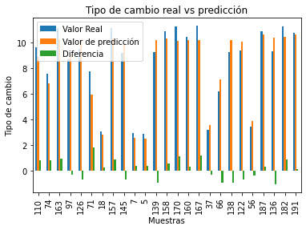

```python
comprobación.plot.bar()
plt.title("Tipo de cambio real vs predicción")
plt.xlabel("Muestras")
plt.ylabel("Tipo de cambio")
plt.show()
```

# Reflexión final (Conclusiones)

### ¿Qué puedes concluir sobre tu proyecto de Ciencia de Datos y cuál fue tu aprendizaje?

Con base en nuestro proyecto de ciencia de datos, ahora quedamos convencidos de lo útil que es esta herramienta para poder resolver problemas. A parte de los aprendizajes indirectos de estadística, matemáticas y programación, aprendimos una forma de pensamiento crítico al poner nuestras hipótesis a prueba en machine learning. En este caso, estuvimos en lo correcto.

### ¿Por qué es importante la Ciencia de Datos y la ética para el uso adecuado de los datos e información?

Es importante porque finalmente la ciencia de datos y el machine learning simplemente analizan números acorde a las instrucciones que les demos. Es decir, simplemente actúan modelando datos en ecuaciones, si arrojamos datos manipulados a nuestra conveniencia, reflejaran estadística que nos satisfaga pero que no tendrá relación con la realidad. O expresado en inglés, garbage in, garbage out.

# Referencias

- ¿Qué es la ciencia de datos? (2014). Oracle.com. https://www.oracle.com/mx/data-science/what-is-data-science/
- Domínguez,2021, Ciencias de Datos en Python [Presentación de Powerpoint]
- Datos-Proyecto. (2021). “Hoja 1”. Recuperado de la base de datos de excel “Datos.xlsx
- IBM Docs. (2021, August 17). Ibm.com. https://www.ibm.com/docs/es/spss-modeler/SaaS?topic=dm-crisp-help-overview